# Factores que determinan la presencia de Didymosphenia geminata en Chile

4 de octubre de 2019

## Introducción

### *Didymosphenia geminata*

- Diatomea
- Bentónica
- Hemisferio Norte

**Hábitat**

- Ecosistemas oligotróficos
- Sustratos rocosos

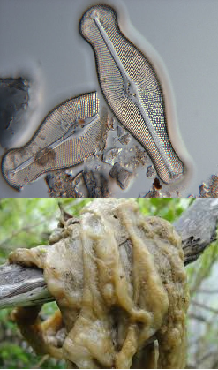

## Introducción

- Actividades antropicas -> Propagación de Didymo

**Didymo en Chile** - Futaleufu (2010), Region de Los Lagos

**Impactos** - Ecológicos (Bentonicos, Macroinvertebrados y Vertebrados) - Sociales, económicos y estéticos

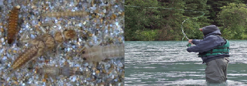

**Objetivo:**

Determinar si la presencia de *Didimosphenia geminata* en Chile se encuentra asociada a parámetros físicoquímicos.

## Métodos

**Área de estudio**:

-Ríos (acuicultura y pesca recreativa)

- 8 Regiones (Maule, Bío-Bío, La Araucanía, Los Ríos, Los Lagos, Aysén, Magallanes y Ñuble)

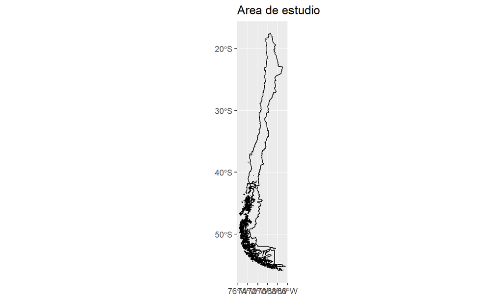

## Métodos

**Obtención de los datos y Análisis de datos**

- Salvo Pereira (2019)
- Durante las épocas de primavera-verano (2018) y otoño-invierno (2019)
- Variables: NO2/NO3/Nt/Nkt/PO4/Pt/Si/Ca/Turbidez
- Correlacionadas
- Modelos lineales - relación entre las variables independientes y la variable dependiente
- Evaluación de los modelos - AIC

## Resultados

**Presencia del Didymo**

394 muestras - 364 presencia y 30 de ausencia de Didymo

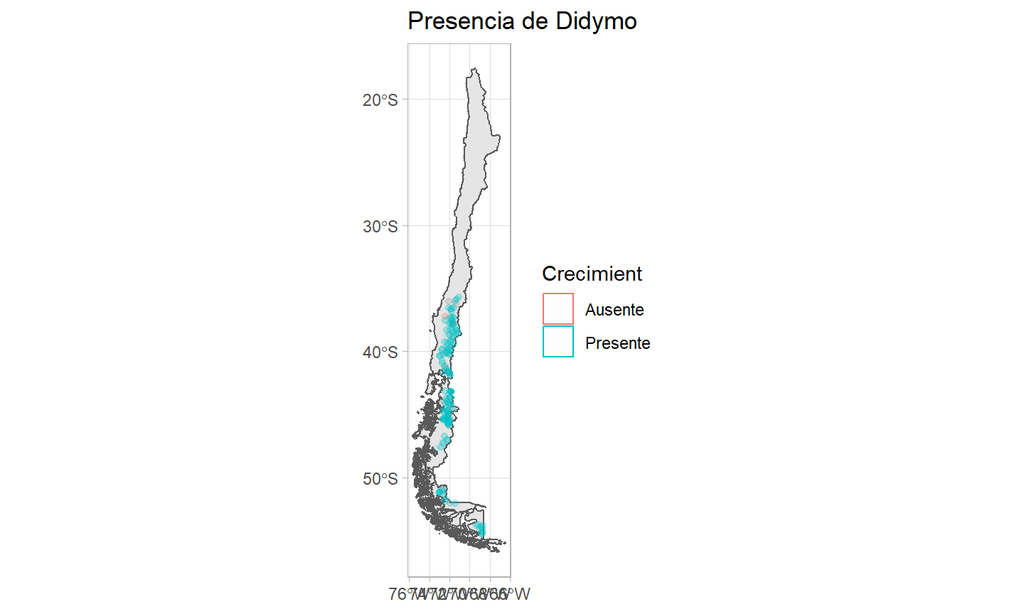

## Resultados

Al realizar varios modelos el mejor fue -> Presencia de Didymo con Fósforo

con un AIC de 35.01814 y un p 9.825e-13

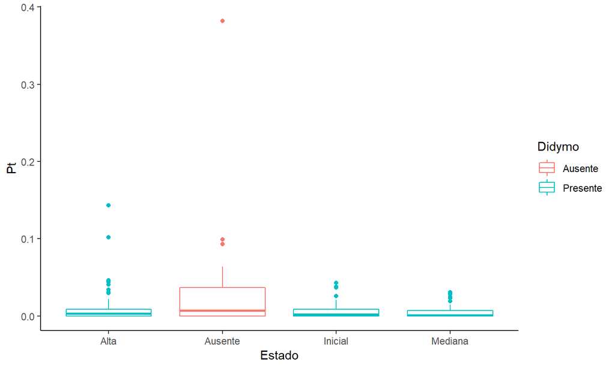

[figure not shown]

**¿Sucede lo mismo con otras diatomeas?**

**Comportamiento del Didymo con el fósforo**

[figure not shown]